# sklearn.compose.ColumnTransformer

**class*sklearn.compose.ColumnTransformer(*transformers*, *, *remainder='drop'*, *sparse_threshold=0.3*, *n_jobs=None*, *transformer_weights=None*, *verbose=False*, *verbose_feature_names_out=True*)[[source]](https://github.com/scikit-learn/scikit-learn/blob/f3f51f9b6/sklearn/compose/_column_transformer.py#L39)**

Applies transformers to columns of an array or pandas DataFrame.

This estimator allows different columns or column subsets of the input to be transformed separately and the features generated by each transformer will be concatenated to form a single feature space. This is useful for heterogeneous or columnar data, to combine several feature extraction mechanisms or transformations into a single transformer.

Read more in the User Guide.

New in version 0.20.

**Parameters:**

**transformers**list of tuples**

List of (name, transformer, columns) tuples specifying the transformer objects to be applied to subsets of the data.

**namestr**

Like in Pipeline and FeatureUnion, this allows the transformer and its parameters to be set using `set_params` and searched in grid search.

**transformer{‘drop’, ‘passthrough’} or estimator**

Estimator must support fit and transform. Special-cased strings ‘drop’ and ‘passthrough’ are accepted as well, to indicate to drop the columns or to pass them through untransformed, respectively.

**columnsstr, array-like of str, int, array-like of int, array-like of bool, slice or callable**

Indexes the data on its second axis. Integers are interpreted as positional columns, while strings can reference DataFrame columns by name. A scalar string or int should be used where `transformer` expects X to be a 1d array-like (vector), otherwise a 2d array will be passed to the transformer. A callable is passed the input data `X` and can return any of the above. To select multiple columns by name or dtype, you can use `make_column_selector`.

**remainder**{‘drop’, ‘passthrough’} or estimator, default=’drop’**

By default, only the specified columns in `transformers` are transformed and combined in the output, and the non-specified columns are dropped. (default of `'drop'`). By specifying `remainder='passthrough'`, all remaining columns that were not specified in `transformers` will be automatically passed through. This subset of columns is concatenated with the output of the transformers. By setting `remainder` to be an estimator, the remaining non-specified columns will use the `remainder` estimator. The estimator must support fit and transform. Note that using this feature requires that the DataFrame columns input at fit and transform have identical order.

**sparse_threshold**float, default=0.3**

If the output of the different transformers contains sparse matrices, these will be stacked as a sparse matrix if the overall density is lower than this value. Use `sparse_threshold=0` to always return dense. When the transformed output consists of all dense data, the stacked result will be dense, and this keyword will be ignored.

**n_jobs**int, default=None**

Number of jobs to run in parallel. `None` means 1 unless in a [`joblib.parallel_backend`](https://joblib.readthedocs.io/en/latest/parallel.html#joblib.parallel_backend) context. `-1` means using all processors. See [Glossary](https://scikit-learn.org/1.1/glossary.html#term-n_jobs) for more details.

**transformer_weights**dict, default=None**

Multiplicative weights for features per transformer. The output of the transformer is multiplied by these weights. Keys are transformer names, values the weights.

**verbose**bool, default=False**

If True, the time elapsed while fitting each transformer will be printed as it is completed.

**verbose_feature_names_out**bool, default=True**

If True, `get_feature_names_out` will prefix all feature names with the name of the transformer that generated that feature. If False, `get_feature_names_out` will not prefix any feature names and will error if feature names are not unique.

New in version 1.0.

**Attributes:**

**transformers_**list**

The collection of fitted transformers as tuples of (name, fitted_transformer, column). `fitted_transformer` can be an estimator, ‘drop’, or ‘passthrough’. In case there were no columns selected, this will be the unfitted transformer. If there are remaining columns, the final element is a tuple of the form: (‘remainder’, transformer, remaining_columns) corresponding to the `remainder` parameter. If there are remaining columns, then `len(transformers_)==len(transformers)+1`, otherwise `len(transformers_)==len(transformers)`.

**`named_transformers_``Bunch`**

Access the fitted transformer by name.

**sparse_output_**bool**

Boolean flag indicating whether the output of `transform` is a sparse matrix or a dense numpy array, which depends on the output of the individual transformers and the `sparse_threshold` keyword.

**output_indices_**dict**

A dictionary from each transformer name to a slice, where the slice corresponds to indices in the transformed output. This is useful to inspect which transformer is responsible for which transformed feature(s).

New in version 1.0.

**n_features_in_**int**

Number of features seen during fit. Only defined if the underlying transformers expose such an attribute when fit.

New in version 0.24.

See also

**`make_column_transformer`**

Convenience function for combining the outputs of multiple transformer objects applied to column subsets of the original feature space.

**`make_column_selector`**

Convenience function for selecting columns based on datatype or the columns name with a regex pattern.

#### Notes

The order of the columns in the transformed feature matrix follows the order of how the columns are specified in the `transformers` list. Columns of the original feature matrix that are not specified are dropped from the resulting transformed feature matrix, unless specified in the `passthrough` keyword. Those columns specified with `passthrough` are added at the right to the output of the transformers.

#### Examples

```
>>> import numpy as np
>>> from sklearn.compose import ColumnTransformer
>>> from sklearn.preprocessing import Normalizer
>>> ct = ColumnTransformer(
...     [("norm1", Normalizer(norm='l1'), [0, 1]),
...      ("norm2", Normalizer(norm='l1'), slice(2, 4))])
>>> X = np.array([[0., 1., 2., 2.],
...               [1., 1., 0., 1.]])
>>> # Normalizer scales each row of X to unit norm. A separate scaling
>>> # is applied for the two first and two last elements of each
>>> # row independently.
>>> ct.fit_transform(X)
array([[0. , 1. , 0.5, 0.5],
       [0.5, 0.5, 0. , 1. ]])
```

`ColumnTransformer` can be configured with a transformer that requires a 1d array by setting the column to a string:

```
>>> from sklearn.feature_extraction import FeatureHasher
>>> from sklearn.preprocessing import MinMaxScaler
>>> import pandas as pd
>>> X = pd.DataFrame({
...     "documents": ["First item", "second one here", "Is this the last?"],
...     "width": [3, 4, 5],
... })
>>> # "documents" is a string which configures ColumnTransformer to
>>> # pass the documents column as a 1d array to the FeatureHasher
>>> ct = ColumnTransformer(
...     [("text_preprocess", FeatureHasher(input_type="string"), "documents"),
...      ("num_preprocess", MinMaxScaler(), ["width"])])
>>> X_trans = ct.fit_transform(X)
```

#### Methods

| `fit`(X[, y]) | Fit all transformers using X. |
| --- | --- |
| `fit_transform`(X[, y]) | Fit all transformers, transform the data and concatenate results. |
| `get_feature_names`() | DEPRECATED: get_feature_names is deprecated in 1.0 and will be removed in 1.2. |
| `get_feature_names_out`([input_features]) | Get output feature names for transformation. |
| `get_params`([deep]) | Get parameters for this estimator. |
| `set_params`(**kwargs) | Set the parameters of this estimator. |
| `transform`(X) | Transform X separately by each transformer, concatenate results. |

**fit(*X*, *y=None*)[[source]](https://github.com/scikit-learn/scikit-learn/blob/f3f51f9b6/sklearn/compose/_column_transformer.py#L638)**

Fit all transformers using X.

**Parameters:**

**X**{array-like, dataframe} of shape (n_samples, n_features)**

Input data, of which specified subsets are used to fit the transformers.

**y**array-like of shape (n_samples,…), default=None**

Targets for supervised learning.

**Returns:**

**self**ColumnTransformer**

This estimator.

**fit_transform(*X*, *y=None*)[[source]](https://github.com/scikit-learn/scikit-learn/blob/f3f51f9b6/sklearn/compose/_column_transformer.py#L660)**

Fit all transformers, transform the data and concatenate results.

**Parameters:**

**X**{array-like, dataframe} of shape (n_samples, n_features)**

Input data, of which specified subsets are used to fit the transformers.

**y**array-like of shape (n_samples,), default=None**

Targets for supervised learning.

**Returns:**

**X_t**{array-like, sparse matrix} of shape (n_samples, sum_n_components)**

Horizontally stacked results of transformers. sum_n_components is the sum of n_components (output dimension) over transformers. If any result is a sparse matrix, everything will be converted to sparse matrices.

**get_feature_names()[[source]](https://github.com/scikit-learn/scikit-learn/blob/f3f51f9b6/sklearn/compose/_column_transformer.py#L411)**

DEPRECATED: get_feature_names is deprecated in 1.0 and will be removed in 1.2. Please use get_feature_names_out instead.

Get feature names from all transformers.

**Returns:**

**feature_names**list of strings**

Names of the features produced by transform.

**get_feature_names_out(*input_features=None*)[[source]](https://github.com/scikit-learn/scikit-learn/blob/f3f51f9b6/sklearn/compose/_column_transformer.py#L470)**

Get output feature names for transformation.

**Parameters:**

**input_features**array-like of str or None, default=None**

Input features.

- If `input_features` is `None`, then `feature_names_in_` is used as feature names in. If `feature_names_in_` is not defined, then the following input feature names are generated: `["x0", "x1", ..., "x(n_features_in_ - 1)"]`.
- If `input_features` is an array-like, then `input_features` must match `feature_names_in_` if `feature_names_in_` is defined.

**Returns:**

**feature_names_out**ndarray of str objects**

Transformed feature names.

**get_params(*deep=True*)[[source]](https://github.com/scikit-learn/scikit-learn/blob/f3f51f9b6/sklearn/compose/_column_transformer.py#L256)**

Get parameters for this estimator.

Returns the parameters given in the constructor as well as the estimators contained within the `transformers` of the `ColumnTransformer`.

**Parameters:**

**deep**bool, default=True**

If True, will return the parameters for this estimator and contained subobjects that are estimators.

**Returns:**

**params**dict**

Parameter names mapped to their values.

**property*named_transformers_**

Access the fitted transformer by name.

Read-only attribute to access any transformer by given name. Keys are transformer names and values are the fitted transformer objects.

**set_params(**kwargs)[[source]](https://github.com/scikit-learn/scikit-learn/blob/f3f51f9b6/sklearn/compose/_column_transformer.py#L276)**

Set the parameters of this estimator.

Valid parameter keys can be listed with `get_params()`. Note that you can directly set the parameters of the estimators contained in `transformers` of `ColumnTransformer`.

**Parameters:**

**kwargsdict**

Estimator parameters.

**Returns:**

**self**ColumnTransformer**

This estimator.

**transform(*X*)[[source]](https://github.com/scikit-learn/scikit-learn/blob/f3f51f9b6/sklearn/compose/_column_transformer.py#L716)**

Transform X separately by each transformer, concatenate results.

**Parameters:**

**X**{array-like, dataframe} of shape (n_samples, n_features)**

The data to be transformed by subset.

**Returns:**

**X_t**{array-like, sparse matrix} of shape (n_samples, sum_n_components)**

Horizontally stacked results of transformers. sum_n_components is the sum of n_components (output dimension) over transformers. If any result is a sparse matrix, everything will be converted to sparse matrices.

## Examples using `sklearn.compose.ColumnTransformer`

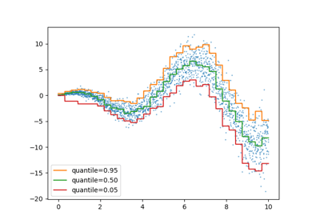

Release Highlights for scikit-learn 1.1

Release Highlights for scikit-learn 1.0

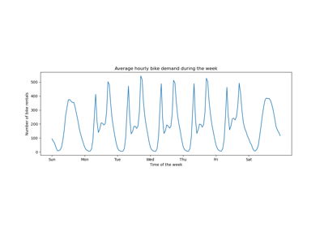

Time-related feature engineering

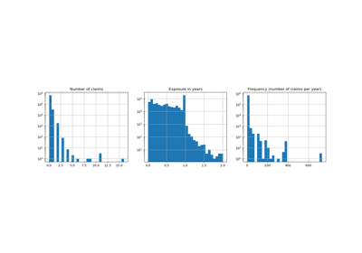

Poisson regression and non-normal loss

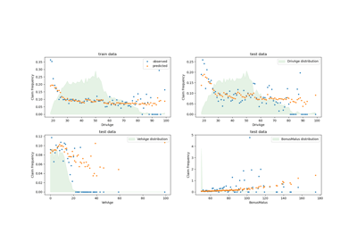

Tweedie regression on insurance claims

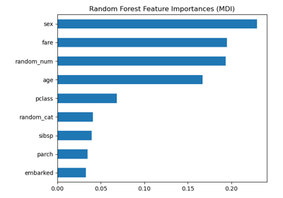

Permutation Importance vs Random Forest Feature Importance (MDI)

Displaying Pipelines

Column Transformer with Heterogeneous Data Sources

Column Transformer with Mixed Types

© 2007–2022 The scikit-learn developers  
Licensed under the 3-clause BSD License.  
https://scikit-learn.org/1.1/modules/generated/sklearn.compose.ColumnTransformer.html